# HIC-ANALYSIS

This dataset contains chromatin interaction data based on HiC-Sequencing which allows us to study genome-wide chromatin interactions and classify the genome into active and repressive genomic compartments. The data has been taken from E. Lieberman-Aiden et al. 2009 and Stadhouders, R., Vidal, E., Serra, F. et al.2018.  
The file “chr14_normalized.txt” contains a distance normailzed hic interaction matrix for chr14. Import the file as a table and convert it to matrix format.

```r
nmat=read.table("chr14_normalized.txt")
nmat=as.matrix(nmat)
```

Visualize the matrix using the ‘image’ command. What does the matrix show?

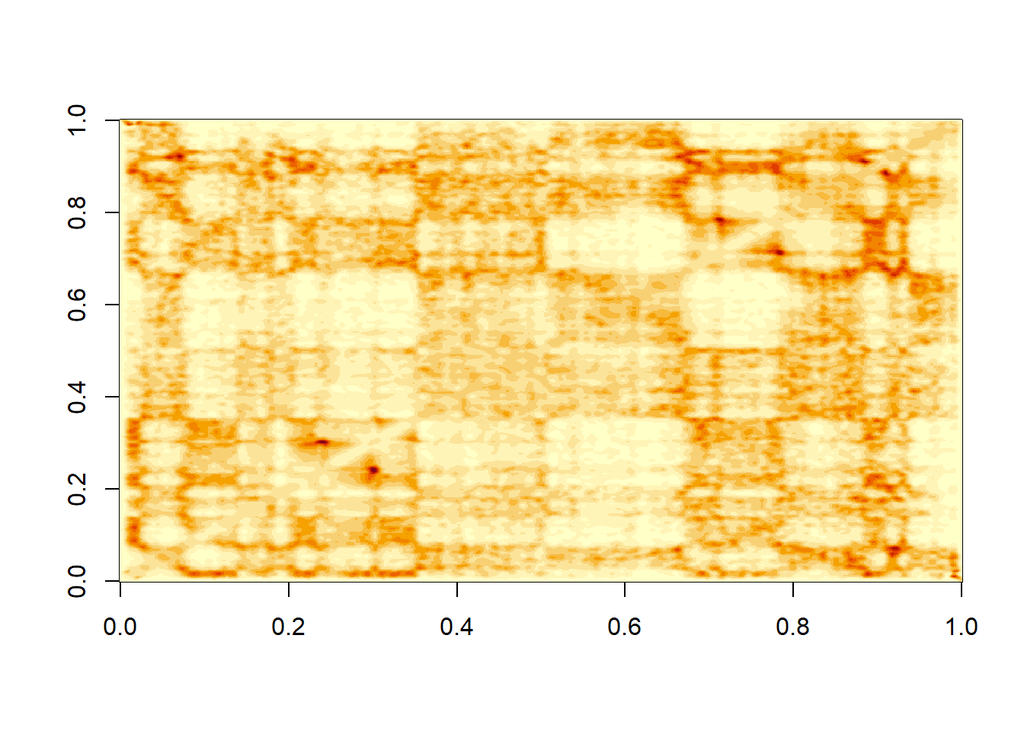

```r
image(nmat)
```

```r
#The matrix shows intra-chromosomal chromatin interactions along the length of the chromosome 14. The matrix is distance normalized and shows statistically significant interactions that are not enriched simply because of proximity.
```

Convert the matrix into a correlation matrix and visualize the correlation matrix with the ‘image’ command (you can use the argument col=colorRampPalette(c(“red”, “white”,“blue”))(256) to show positive and negative values as red and blue colors )

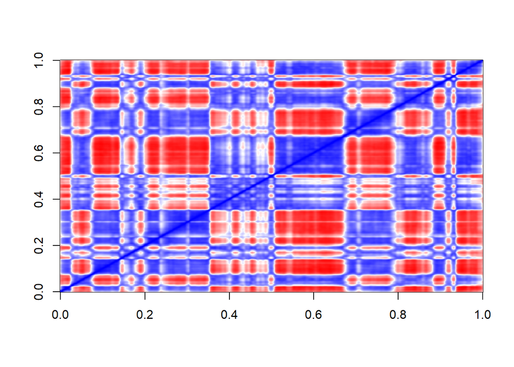

```r
cm=cor(nmat)
image(cm,col=colorRampPalette(c("red", "white","blue"))(256))
```

What does the alternating checkerboard pattern represent?

```r
#The alternating blue and red boxes show that the chromosome can be divided into two types of regions based on their interaction frequencies.

#Regions belonging to the same category show positive correlation of interaction frequencies with each other and negative correlation with regions belonging to the other category.

#Such regions alternate along the chromosome and represent spatially segregated genomic compartments
```

Perform PCA analysis on the correlation matrix and store the results

```r
pc=princomp(cm)
```

Create a new dataframe with two columns. One column should contain the coordinate of each genomic bin in the matrix (i.e. rownames of the original matrix in numeric format) and the second column should contain its PC1 value (these are stored in the first column of the ‘loadings’ dataframe in the PCA object).

```r
pc1=data.frame(coordinate=as.numeric(rownames(nmat)),pc1=pc$loadings[,1])
```

Use ggplot to make a plot of PC1 values along the length of the chromosome. Use geom_area() with pc1 on y-axis and coordinates on x-axis.

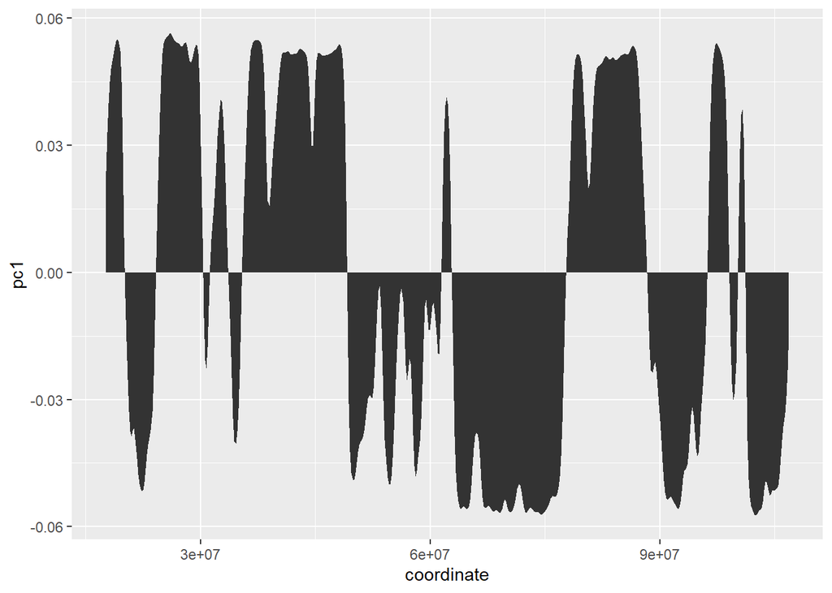

```r
ggplot(pc1,aes(x=coordinate,y=pc1))+geom_area()
```

Compare the PC1 plot with the correlation matrix. How do the pc1 values correlate with the alternating pattern observed in the correlation matrix?

```r
#The alternating compartment identities seem to correspond with the sign of the pc1 values.

#One compartment has negative pc1 values and the other positive pc1 values allowing us to identify compartment based on pca analysis
```

# How genomic compartments change during differentiation?

We want to study how genomic compartments change during the process of differentiation. We will use data from (Stadhouders, R., Vidal, E., Serra, F. et al.2018) who reprogrammed b-cells into plouripotent stem cells and performed HiC sequencing before and after reprogramming.  
The file ‘bcellvspsc_50kb.csv’ contains the results of PCA analysis on HiC data at 50kb resolution. Rows represent 50kb genomic regions. First two columns contain PC1 value of each region in bcells and PSCs, the third column shows the avg change in rna-seq expression of all genes whose TSSs lie in that region

```r
#import the file in a dataframe
compartments=read.csv("bcellvspsc_50kb.csv")
```

We want to find out how many 50kb bins changed their PC1 values from postive to negative or negative to positive during reprogramming and how many remain unchanged.

```r
#Add a new column called 'Type' to the dataframe and label each region as belonging to one of 3 categories : "pos2neg","neg2pos","unchanged"

compartments$Type="unchanged"
compartments[compartments$bcell<0 & compartments$psc>0,"Type"]="neg2pos"
compartments[compartments$bcell>0 & compartments$psc<0,"Type"]="pos2neg"
```

What percentage of bins switched from one state to another during differentiation and what percentage remain unchanged? You can also show this as a barplot

```r
table(compartments$Type)/nrow(compartments)*100
```

```
##
##   neg2pos   pos2neg unchanged
## 10.754062  8.973694 80.272245
```

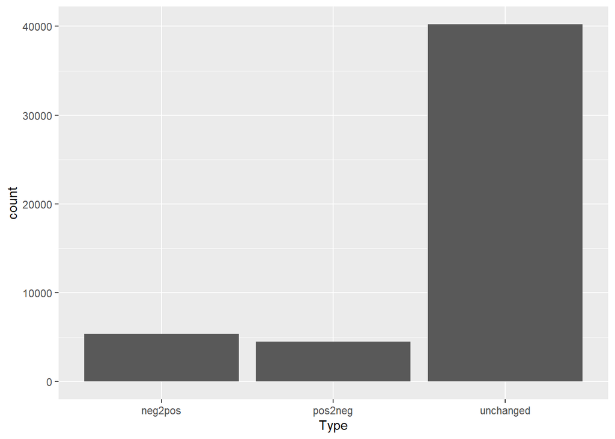

```r
ggplot(compartments,aes(x=Type))+geom_bar()
```

Make a boxplot of the avg expression of genes belonging to different compartment categories

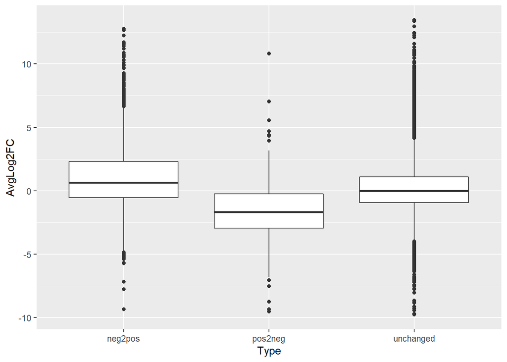

```r
ggplot(compartments,aes(x=Type,y=AvgLog2FC))+geom_boxplot()
```

What does the boxplot tell us?

```r
#Regions whose pc1 value changed from positive to negative showed transcriptional downregulation while those whose pc1 value changed from neg2pos showed upregulation
```

Use one-wat ANOVA to check if the changes observed in th boxplot statistically significant and perform the TukeyHSD test to perform pariwise comparisons

```r
a1=aov(data=compartments,AvgLog2FC~Type)
summary(a1)
```

```
##                Df Sum Sq Mean Sq F value Pr(>F)
## Type            2   2992  1496.1   291.6 <2e-16 ***
## Residuals   11982  61473     5.1
## ---
## Signif. codes:  0 '***' 0.001 '**' 0.01 '*' 0.05 '.' 0.1 ' ' 1
## 38117 observations deleted due to missingness
```

```r
#Use Tukey test to do pairwise comparisons
TukeyHSD(a1)
```

```
##   Tukey multiple comparisons of means
##     95% family-wise confidence level
##
## Fit: aov(formula = AvgLog2FC ~ Type, data = compartments)
##
## $Type
##                         diff       lwr       upr p adj
## pos2neg-neg2pos   -2.7150116 -2.982029 -2.447994     0
## unchanged-neg2pos -0.9546383 -1.103665 -0.805612     0
## unchanged-pos2neg  1.7603733  1.526420  1.994327     0
```